# Session3: Data wrangling

## `summarize()`: Summarize the data

- `summarize()` creates a new table of summary statistics (Maps a vector to a scalar).
- `summarize(x, y = f(z))`: Apply `f` to the variable `z` in `x` and call it `y`.
- Some example functions: `sum(z)`, `mean(z)`, `median(z)`, `min(z)`, `max(z)`.
- Allows user-defined functions.
- `summarise()` works as well.

Example:

```r
summarize(diamonds, avg_price = mean(price))
```

```
## # A tibble: 1 × 1
##   avg_price
##       <dbl>
## 1     3933.
```

## `summarize()`: in action

- allows user-defined functions (takes a vector and returns a scalar)

```r
ssq <- function(x){
  return(sum(x^2))
}
summarize(diamonds, ssq_price = ssq(price))
```

```
## # A tibble: 1 × 1
##       ssq_price
##           <dbl>
## 1 1692758457943
```

## `summarize()`: in action

- can output multiple summaries!

```r
summarize(diamonds,
          mean_price = mean(price),
          median_price = median(price))
```

```
## # A tibble: 1 × 2
##   mean_price median_price
##        <dbl>        <dbl>
## 1      3933.         2401
```

## `summarize()`: apply multiple function for multiple columns at once

```r
summarize(diamonds,
          me_price = mean(price),
          medi_price = median(price),
          me_carat = mean(carat),
          medi_carat = median(carat))
```

```
## # A tibble: 1 × 4
##   me_price medi_price me_carat medi_carat
##      <dbl>      <dbl>    <dbl>      <dbl>
## 1    3933.       2401    0.798        0.7
```

```r
summarise(diamonds,
          across(c(price, carat),
                 list(me = mean, medi = median),
                 .names = "{.fn}_{.col}"))
```

```
## # A tibble: 1 × 4
##   me_price medi_price me_carat medi_carat
##      <dbl>      <dbl>    <dbl>      <dbl>
## 1    3933.       2401    0.798        0.7
```

## `summarize()`: summarize the data

- `summarize()` takes a vector and return a scalar value and thus disregards other variables in the data.
- Sometimes, we are interested in looking at group-specific summaries.
- E.g: Average price based on cut.

## `group_by()`: group the data

- Now any functions we apply will be based on the grouping, eg. `summarize()`, `filter()`, `mutate()`, etc.

## `group_by()`: in action

```r
diamonds_cut <- group_by(diamonds, cut)
summarize(diamonds_cut,
          mean_price = mean(price),
          median_price = median(price))
```

```
## # A tibble: 5 × 3
##   cut       mean_price median_price
##   <ord>          <dbl>        <dbl>
## 1 Fair           4359.        3282
## 2 Good           3929.        3050.
## 3 Very Good      3982.        2648
## 4 Premium        4584.        3185
## 5 Ideal          3458.        1810
```

## Applying more than one transformation

- Oftentimes, we want to apply multiple transformation to the data, eg. `filter()`, `mutate()`, etc.
- `dplyr` provides an *easier and cleaner* way to apply multiple transformations through pipe function!

## The pipe function

The pipe function `|>` (or %>%) is essentially a transformation of a data frame to another data frame.

Think about it as an assembly line!

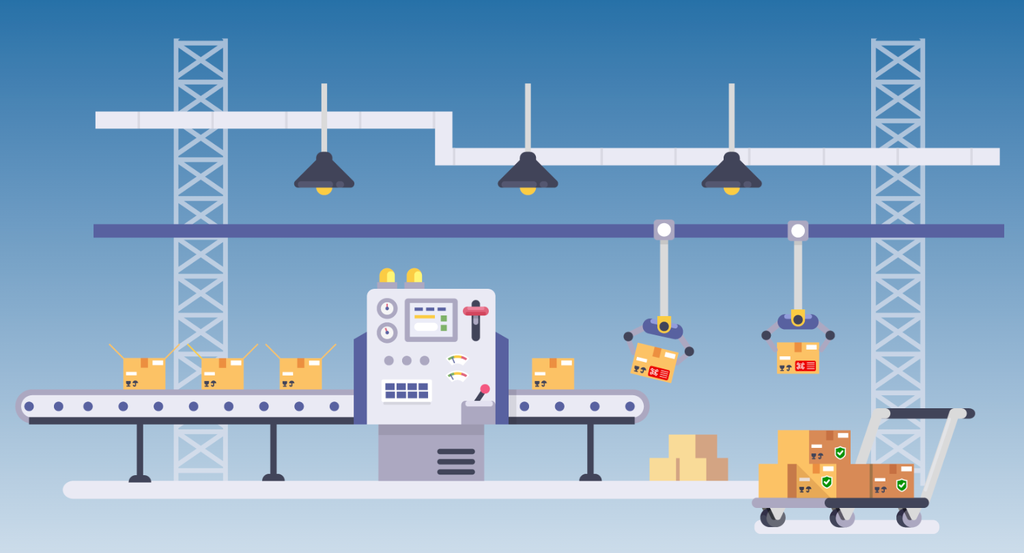

## Excercises (revisited)

```r
diamonds_cut <- group_by(diamonds, cut)
summarize(diamonds_cut,
          mean_price = mean(price),
          median_price = median(price))
```

```
## # A tibble: 5 × 3
##   cut       mean_price median_price
##   <ord>          <dbl>        <dbl>
## 1 Fair           4359.        3282
## 2 Good           3929.        3050.
## 3 Very Good      3982.        2648
## 4 Premium        4584.        3185
## 5 Ideal          3458.        1810
```

## Exercise (revisited): use pipe function

```r
diamonds |>
  group_by(cut) |>
  summarize(mean_price = mean(price),
            median_price = median(price))
```

```
## # A tibble: 5 × 3
##   cut       mean_price median_price
##   <ord>          <dbl>        <dbl>
## 1 Fair           4359.        3282
## 2 Good           3929.        3050.
## 3 Very Good      3982.        2648
## 4 Premium        4584.        3185
## 5 Ideal          3458.        1810
```

## Exercises: multiple transformations

```r
diamonds |>
  select(cut, color, clarity, carat) |>
  filter(clarity == "IF" & cut == "Ideal")
```

```
## # A tibble: 1,212 × 4
##    cut   color clarity carat
##    <ord> <ord> <ord>   <dbl>
##  1 Ideal F     IF       0.52
##  2 Ideal G     IF       0.55
##  3 Ideal G     IF       0.64
##  4 Ideal G     IF       0.61
##  5 Ideal F     IF       0.53
##  6 Ideal G     IF       0.62
##  7 Ideal G     IF       0.62
##  8 Ideal I     IF       0.71
##  9 Ideal I     IF       0.74
## 10 Ideal G     IF       0.64
## # ℹ 1,202 more rows
```

## Exercises: plotting

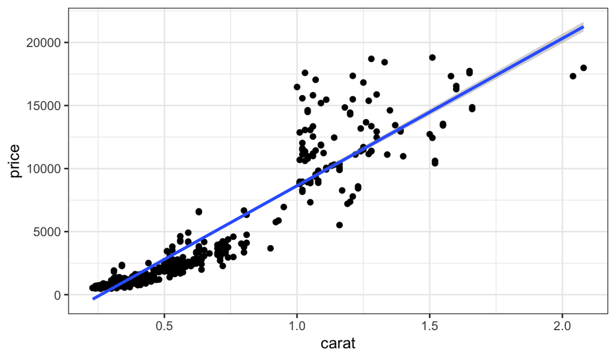

```r
diamonds |>
  filter(clarity == "IF" & cut == "Ideal") |>
  ggplot(aes(x = carat, y = price)) +
  geom_point() +
  geom_smooth(method = "lm")+
  theme_bw()
```

## `dplyr`: Merging data

- `inner_join(x, y, by = ...)`: keep only matching rows from both datasets
- `left_join(x, y, by = ...)`: keep all rows from x, add matches from y
- `right_join(x, y, by = ...)`: keep all rows from y, add matches from x
- `full_join(x, y, by = ...)`: keep all rows from both x and y (union)
- `anti_join(x, y, by = ...)`: keep rows from x that do not have a match in y
- `semi_join(x, y, by = ...)`: keep rows from x that do have a match in y (but don’t add y’s columns)

## `inner_join()`: example data

Let’s create some example data for `inner_join` visualization:

```r
x <- tibble(
  id = c(1, 2, 3),
  value_x = c("x1", "x2", "x3")
)

y <- tibble(
  id = c(1, 2, 4),
  value_y = c("y1", "y2", "y4")
)
```

## `inner_join()`: in action

**keep only matching rows from both datasets**

```r
inner_join(x, y, by = "id")
```

```
## # A tibble: 2 × 3
##      id value_x value_y
##   <dbl> <chr>   <chr>
## 1     1 x1      y1
## 2     2 x2      y2
```

[video not shown]

## `left_join()`: in action

**keep all rows from x, add matches from y**

```r
left_join(x, y, by = "id")
```

```
## # A tibble: 3 × 3
##      id value_x value_y
##   <dbl> <chr>   <chr>
## 1     1 x1      y1
## 2     2 x2      y2
## 3     3 x3      <NA>
```

[video not shown]

```r
x <- tibble(
  id = c(1, 2, 3),
  value_x = c("x1", "x2", "x3")
)

y <- tibble(
  id = c(1, 2, 2, 4),
  value_y = c("y1", "y2", "y2", "y4")
)
```

```r
inner_join(x, y, by = "id")
```

```
## # A tibble: 3 × 3
##      id value_x value_y
##   <dbl> <chr>   <chr>
## 1     1 x1      y1
## 2     2 x2      y2
## 3     2 x2      y2
```

[video not shown]

## `right_join()`: in action

**keep all rows from y, add matches from x (equal to `left_join(y, x, by = "id")`)**

```r
right_join(x, y, by = "id")
```

[output not shown]

[video not shown]